# MA331-Report: 2212220

TED Talks by Speaker Nina Tandon and Speaker Erik Brynjolfsson

Soliu Kafayat

2023-03-28

## Intoduction

The purpose of this analysis is to explore the TED Talks dataset and gain insights into the talks given by two specific speakers: Nina Tandon who is a biomedical engineer,she is also the CEO and Co-Founder of Epi-Bone and Erik Brynjolfsson is an American academic, inventor and author.Nina Tandon’s presentation titled “Caring for engineered tissue” was posted in 2011 while Erik brynjolfsson’s presentation titled “The key to growth?Race with machines” was posted in 2013. In this report, I will use various text analysis techniques for data exploration and result visualization to provide insight into the lexical choices of these speakers and the association between sentiment and the speaker’s talk.

To achieve this, I will use R and several R libraries such as dsEssex, tidy text, ggplot2, dplyr, and ggrepel. I will begin by loading and cleaning the dataset, tokenizing and removing stop words. Next, I will create visualizations of the most common words used by each speaker and their sentiment, and explore the relationship between sentiment and the speaker’s talk.

The findings of this analysis will provide insight into the communication styles and topics of Nina Tandon and Erik Brynjolfsson, and will contribute to a better understanding of the TED Talks dataset.

## Methodology

start -> load_packages -> load_dataset -> filter_dataset -> tokenize_and_clean -> calculate_word_frequency -> visualize_top_words -> perform_sentiment_analysis -> visualize_sentiment_scores -> calculate_sentiment_counts -> calculate_odds_ratio -> visualize_odds_ratio -> perform_association_analysis -> visualize_association -> end

[interactive chart not shown]

## Results

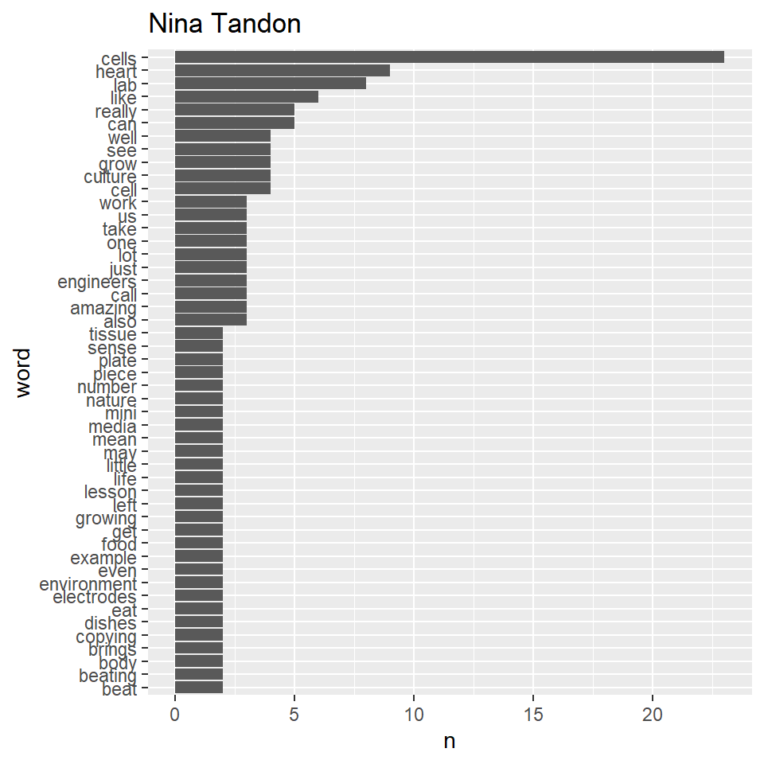

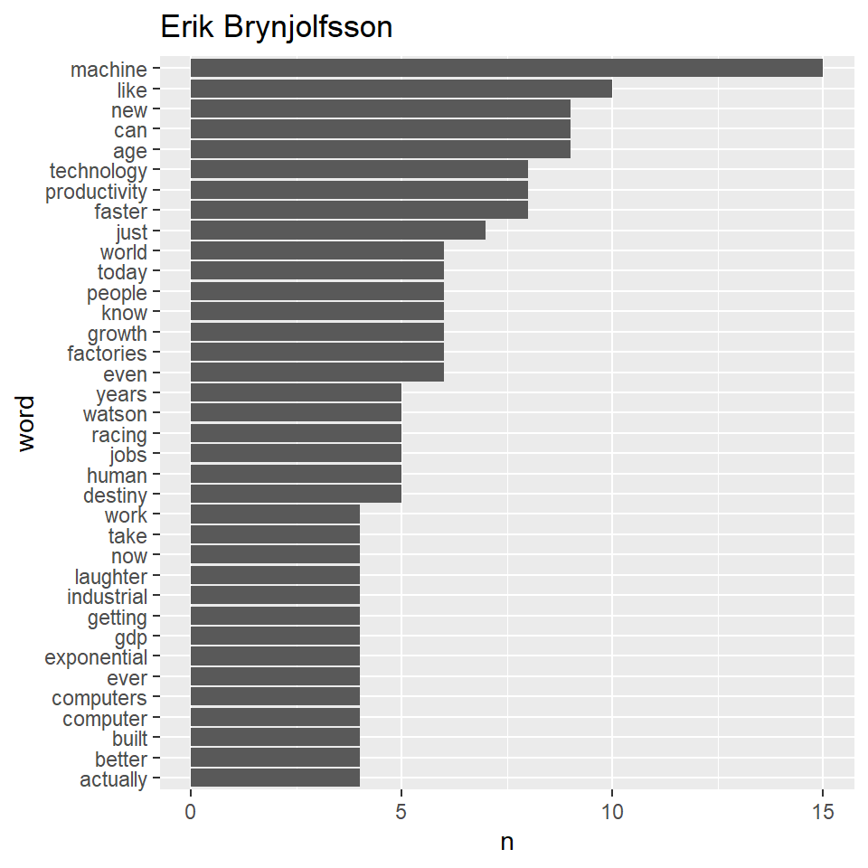

visualize the relationship between the first and second speaker using ggrepel library

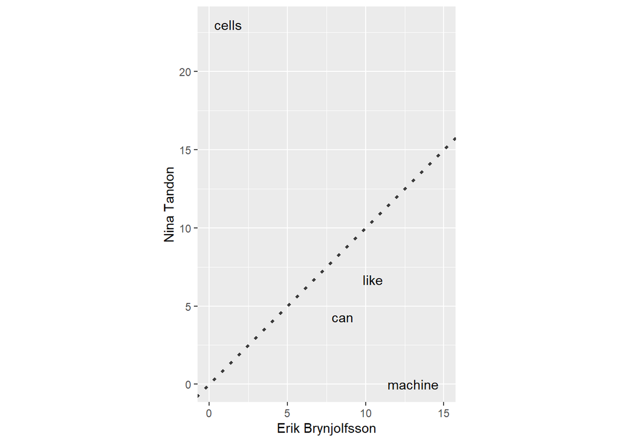

#### visual display of speakers sentiment score

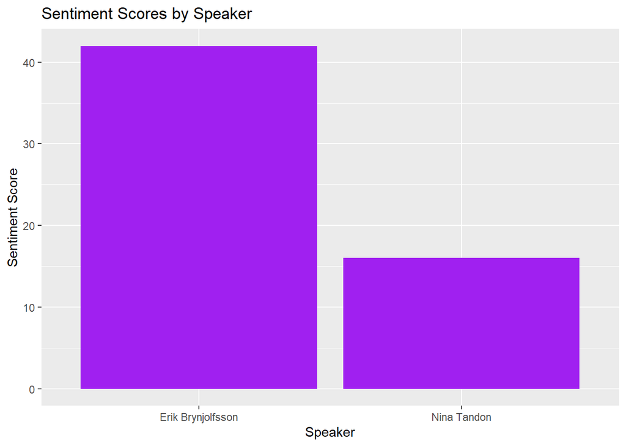

visual display of speakers sentiment score

```
## # A tibble: 322 × 4
##    speaker     word        n sentiment
##    <chr>       <chr>   <int> <chr>
##  1 Nina Tandon culture     4 positive
##  2 Nina Tandon grow        4 anticipation
##  3 Nina Tandon grow        4 joy
##  4 Nina Tandon grow        4 positive
##  5 Nina Tandon grow        4 trust
##  6 Nina Tandon beating     2 anger
##  7 Nina Tandon beating     2 fear
##  8 Nina Tandon beating     2 negative
##  9 Nina Tandon beating     2 sadness
## 10 Nina Tandon eat         2 positive
## # … with 312 more rows
```

Sentiment Counts per each speaker

```
## # A tibble: 10 × 3
##    sentiment    `Erik Brynjolfsson` `Nina Tandon`
##    <chr>                      <int>         <int>
##  1 anger                          8             5
##  2 anticipation                  25            10
##  3 disgust                        8             7
##  4 fear                          13             8
##  5 joy                           21             9
##  6 negative                      21            12
##  7 positive                      63            28
##  8 sadness                       14             6
##  9 surprise                      11             6
## 10 trust                         34            13
```

Speakers sentiment odds ratios

```
## # A tibble: 10 × 5
##    sentiment    `Erik Brynjolfsson` `Nina Tandon`    OR  log_OR
##    <fct>                      <int>         <int> <dbl>   <dbl>
##  1 anger                          8             5 0.754 -0.282
##  2 anticipation                  25            10 1.22   0.197
##  3 disgust                        8             7 0.528 -0.639
##  4 fear                          13             8 0.761 -0.273
##  5 joy                           21             9 1.13   0.118
##  6 negative                      21            12 0.817 -0.202
##  7 positive                      63            28 1.10   0.0982
##  8 sadness                       14             6 1.12   0.114
##  9 surprise                      11             6 0.868 -0.142
## 10 trust                         34            13 1.29   0.257
```

sentiment analysis using nrc lexicon and Log Odd Ratios of Sentiment use by the two speakers

[figure not shown]

## Summary(my_speakers_words)

```
##    speaker              word                 n
##  Length:724         Length:724         Min.   : 1.00
##  Class :character   Class :character   1st Qu.: 1.00
##  Mode  :character   Mode  :character   Median : 1.00
##                                        Mean   : 1.61
##                                        3rd Qu.: 2.00
##                                        Max.   :23.00
```

## conclusion

The result of the analysis show that the two speakers have different subject matters which is reflected in their sentiment and their use of language.

Erik Brynjolfsson repeated the word like many times as the word was used to describe and relate technology and growth to some words like mind,brain,idea and that makes him has the highest number of positive words and he frequently used the word jeopardy to let us know that Growth is not dead as his topic implies and this made him to have the highest number of negative words While Nina Tandon has like has her highest positive words too as she used it to relate cells to different sense of organs and life in general and she she has the lowest number of negative words because most of the negative words was said just once.